# Analysis of Transimission Type and MPG: An Exploratory Study

Sam

2025-02-06

## Introduction

### *Background*

Miles Per Gallon (MPG) is a critical metric for both car buyrs and manufacturers.  
For Car buyers:  
**1. Feulcost:** Higher MPG means more miles for each gallon of feul, leading to less fuel expenses. With fluctuating fuel prices, a vehicle’s fuel efficiency can significantly affect your budget. For example, a car with 30 MPG will cost about half as much to fuel as one with 15 MPG, assuming the same driving conditions.

**2. Environmental Impact:** Vehicles with higher MPG produce fewer emissions per mile, making them more environmentally friendly. For buyers conscious of their carbon footprint, higher MPG vehicles are often more attractive.

**3. Resale Value:** Fuel-efficient cars tend to hold their value better over time. As fuel costs continue to be a significant expense, cars with better MPG remain appealing in the used car market.

**4. Government Incentives:** In many regions, there are tax credits or rebates for purchasing fuel-efficient or low-emission vehicles, providing a financial incentive for buyers to choose cars with higher MPG.

For Manufacturers:  
**1. Regulatory Compliance:** Governments worldwide are setting stricter fuel efficiency and emissions standards. Higher MPG helps manufacturers meet these regulations, avoiding fines and penalties. In the U.S., the Corporate Average Fuel Economy (CAFE) standards require automakers to achieve an average fuel efficiency across their fleets.

**2. Market Demand:** As buyers become more fuel-conscious, demand for fuel-efficient vehicles increases. Manufacturers who prioritize higher MPG can capture a larger share of the market.

**Brand Image:** Producing fuel-efficient vehicles can enhance a manufacturer’s reputation as an environmentally responsible and innovative company. Brands known for their eco-friendly options often attract more customers.

**4. Technological Innovation:** Focusing on MPG drives innovation in automotive technology, leading to advancements in engine design, aerodynamics, and lightweight materials. This can also spill over into other areas of vehicle performance and safety.

### *Research Questions:*

- Is an automatic or manual transmission better for MPG?  
- How much does transmission type affect MPG?

### *Dataset*

The dataset being used is “mtcars” in R containing 32 sample car data including various key variables. This is how it looks:

```r
data(mtcars)
head(mtcars)
```

```
##                    mpg cyl disp  hp drat    wt  qsec vs am gear carb
## Mazda RX4         21.0   6  160 110 3.90 2.620 16.46  0  1    4    4
## Mazda RX4 Wag     21.0   6  160 110 3.90 2.875 17.02  0  1    4    4
## Datsun 710        22.8   4  108  93 3.85 2.320 18.61  1  1    4    1
## Hornet 4 Drive    21.4   6  258 110 3.08 3.215 19.44  1  0    3    1
## Hornet Sportabout 18.7   8  360 175 3.15 3.440 17.02  0  0    3    2
## Valiant           18.1   6  225 105 2.76 3.460 20.22  1  0    3    1
```

### *Methodology*

Analysis of this data set will be conducted by firstly exploring the data set by exploratory analysis where summary(), table() and ggplot() codes will be used following up with correlation Analysis, group comparisons and key observations. Then, model selection will be conducted to fit simple and multiple linear regression, and interaction models and note the observations. Residual analysis and model diagnostics will be conducted following up with statistical inference and testing.

## Exploratory Data analysis

#### MPG and Transmission

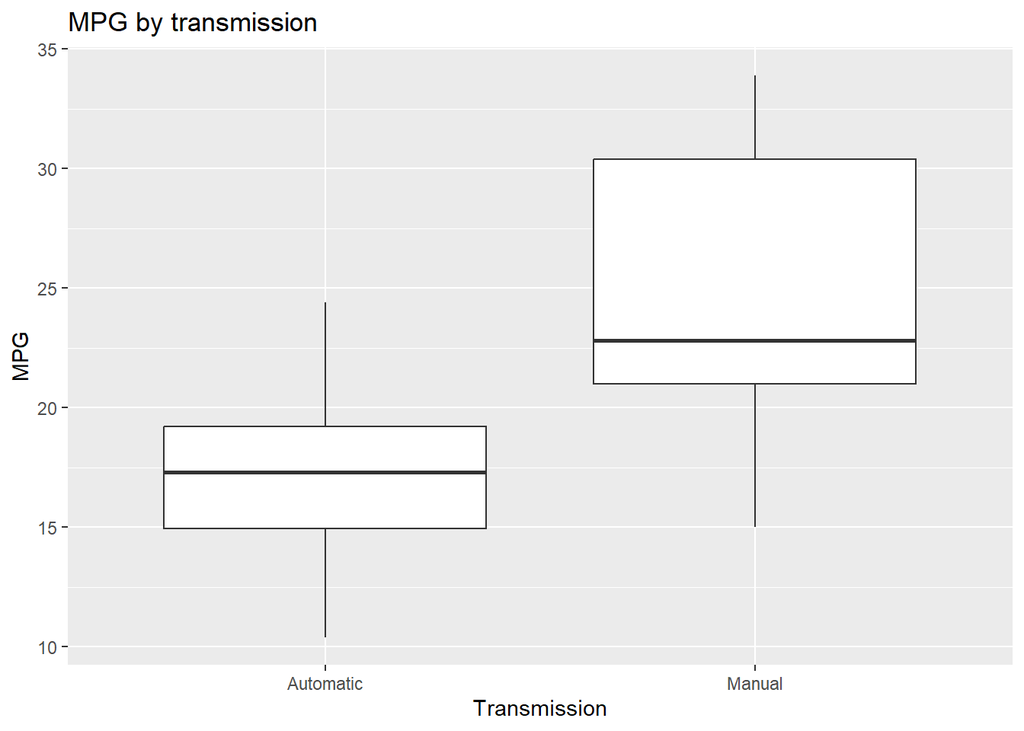

```r
library(ggplot2)
ggplot(mtcars, aes(x= factor(am), y=mpg))+
geom_boxplot() +
  labs(title = "MPG by transmission", x = "Transmission", y = "MPG") +
   scale_x_discrete(labels = c("0" = "Automatic", "1" = "Manual"))
```

We see in the graph comparison between MPG and Transmission, the MPG median and 50% of sample cars with automatic Transmission is less than the MPG and 50% of sample cars with manual Transmission which suggests that the manual transmission cars have higher MPG in the given data set.